# Tarea 1 mejorada: Entrega de ejercicios de Introducción a R

Author

Elizabeth Jiménez Meráz

Published

November 27, 2026

# 2. Introducción a R

## 2.11

Instrucciones: Actividad: comprobar que el entorno está listo 1.

1. Abre RStudio Desktop.
2. Ejecuta `R.version.string` y `Sys.info()[["sysname"]]`.

```r
R.version.string
```

```
[1] "R version 4.6.1 (2026-06-24)"
```

```r
Sys.info()[["sysname"]]
```

```
[1] "Linux"
```

2. Comprueba que `ggplot2` y `dplyr` están instalados; si no lo están, instálalos desde CRAN.

   ```r
   "ggplot2" %in% rownames(installed.packages())
   ```

   ```
   [1] TRUE
   ```

   ```r
   "dplyr" %in% rownames(installed.packages())
   ```

   ```
   [1] TRUE
   ```

   Sí están instalados.
3. Carga ambos paquetes y consulta sus versiones.

   ```r
   library(ggplot2)
   library(dplyr)
   ```

   ```r
   packageVersion("ggplot2")
   ```

   ```
   [1] '4.0.3'
   ```

   ```r
   packageVersion("dplyr")
   ```

   ```
   [1] '1.2.1'
   ```

   La versión de `ggplot2` instalada en mi R es: 4.0.3 y la de `dplyr` es: 1.2.1
4. Identifica las herramientas de compilación correspondientes a tu sistema operativo. En Windows, comprueba especialmente la compatibilidad de Rtools.

   ```r
   # install.packages("pkgbuild")

   pkgbuild::has_build_tools(debug = TRUE)
   ```

   ```
   [1] TRUE
   ```

La función usada verifica automáticamente el sistema operativo y confirma si existen los compiladores necesarios (como Rtools o Xcode) o qué es exactamente lo que falta instalar. Linux es mi sistema operativo, sí tengo las herramientas de compilación necesarias.

# 3. Objetos y estructuras de datos en R

## 3.2.1

Ejercicio 1. Vectores y selección

```r
# Crear los vectores:
ids <- c("g1", "g2", "g3", "g4", "g5")
tam <- c(90, 450, 310, 120, 600)
```

1. Selecciona el tercer identificador.

```r
ids[3]
```

```
[1] "g3"
```

2. Recupera los identificadores de genes con longitud de al menos 300.

```r
ids[tam >= 300]
```

```
[1] "g2" "g3" "g5"
```

3. Cuenta cuántos cumplen esa condición sin usar un ciclo.

```r
sum(tam >= 300)
```

```
[1] 3
```

## 3.2.4

Ejercicio 2: Factores

Crea una vector con las letras A M A B M M B A B B, donde A significa Alto, B bajo y M medio. Convierte las entradas del vector a factores y especifica que A > M > B.

```r
letras <- c("A", "M", "A", "B", "M", "M", "B", "A", "B", "B")
letras2 <- factor(c("A", "M", "A", "B", "M", "M", "B", "A", "B", "B"), levels = c("A", "M", "B")) # siempre el que escribes primero es el que toma como el más grande y viceverza
letras2
```

```
 [1] A M A B M M B A B B
Levels: A M B
```

## 3.2.5

Ejercicio 3: Elegir estructuras

1. Construye un `data.frame` con tres genes, sus longitudes y una etiqueta funcional.

```r
Ejercicio3.df <- data.frame(gen = c("g1", "g2", "g3"),
                            longitud = c(501, 100, 267),
                            funcion = c("enzima", "arnm", "arnr"))
```

2. Recupera únicamente las filas con longitud mayor que 200.

```r
mayor200 <- Ejercicio3.df[Ejercicio3.df$longitud>200,]
mayor200
```

```
  gen longitud funcion
1  g1      501  enzima
3  g3      267    arnr
```

3. Crea una lista que contenga la tabla y el identificador de una muestra.

```r
Ejercicio3.ls <- list(muestra = "Muestra_1", genes = Ejercicio3.df)
Ejercicio3.ls
```

```
$muestra
[1] "Muestra_1"

$genes
  gen longitud funcion
1  g1      501  enzima
2  g2      100    arnm
3  g3      267    arnr
```

4. Explica por qué una matriz de caracteres no sería una buena sustitución para la tabla cuando queremos conservar longitudes numéricas.

   Una matriz no sería la mejor opción porque solo conserva elementos del mismo tipo, y dado que en la tabla tenemos caracteres y numéricos, los numéricos (que en este caso representan la longitud del gen) se convertirían a caracteres. De esta forma ya no son útiles para hacer comparaciones y por ejemplo “filtrar” lo que son más grandes o pequeños que cierta cantidad.

# 4. Estructuras de control

## 4.1.1

Ejercicio 1: Clasificación de un valor

Define una variable conteo que represente el número de lecturas asignadas a un gen. Escribe un condicional que imprima:

- “Dato faltante” si el valor es `NA`.
- “Conteo inválido” si es negativo.
- “Sin lecturas” si es cero.
- “Con lecturas” si es positivo.

Prueba tu código con `NA`, `-2`, `0` y `15`.

```r
conteo <- NA
if (anyNA(conteo) == TRUE){
  cat("Al probar con", conteo, ": Dato faltante", "\n")
} else if(conteo < 0) {
  cat("Al probar con", conteo, ": conteo inválido", "\n")
} else if (conteo == 0){
  cat("Al probar con", conteo, ": sin lecturas", "\n")
} else if (conteo > 0){
  cat("Al probar con", conteo, ": con lecturas", "\n")
}
```

```
Al probar con NA : Dato faltante
```

```r
conteo <- -2
if (anyNA(conteo) == TRUE){
  cat("Al probar con", conteo, ": Dato faltante", "\n")
} else if(conteo < 0) {
  cat("Al probar con", conteo, ": conteo inválido", "\n")
} else if (conteo == 0){
  cat("Al probar con", conteo, ": sin lecturas", "\n")
} else if (conteo > 0){
  cat("Al probar con", conteo, ": con lecturas", "\n")
}
```

```
Al probar con -2 : conteo inválido
```

```r
conteo <- 0
if (anyNA(conteo) == TRUE){
  cat("Al probar con", conteo, ": Dato faltante", "\n")
} else if(conteo < 0) {
  cat("Al probar con", conteo, ": conteo inválido", "\n")
} else if (conteo == 0){
  cat("Al probar con", conteo, ": sin lecturas", "\n")
} else if (conteo > 0){
  cat("Al probar con", conteo, ": con lecturas", "\n")
}
```

```
Al probar con 0 : sin lecturas
```

```r
conteo <- 15
if (anyNA(conteo) == TRUE){
  cat("Al probar con", conteo, ": Dato faltante", "\n")
} else if(conteo < 0) {
  cat("Al probar con", conteo, ": conteo inválido", "\n")
} else if (conteo == 0){
  cat("Al probar con", conteo, ": sin lecturas", "\n")
} else if (conteo > 0){
  cat("Al probar con", conteo, ": con lecturas", "\n")
}
```

```
Al probar con 15 : con lecturas
```

## 4.1.2

Ejercicio 2. Verificación de conteos

Considera el vector `conteos <- c(8, 0, 13, 5, 0, 21)`. Utiliza las funciones anteriores para:

1. Verificar si todos los valores son no negativos.

```r
conteos <- c(8, 0, 13, 5, 0, 21)
any(conteos == 0)
```

```
[1] TRUE
```

2. Determinar si existe al menos un conteo mayor que 20.

```r
any(conteos > 20)
```

```
[1] TRUE
```

3. Obtener las posiciones de los conteos iguales a cero.

```r
which(conteos == 0)
```

```
[1] 2 5
```

4. Crear un vector que indique “Presente” o “Ausente” según si el conteo es mayor que cero.

```r
estado <- ifelse(conteos > 0, "Presente", "Ausente")
estado
```

```
[1] "Presente" "Ausente"  "Presente" "Presente" "Ausente"  "Presente"
```

## 4.2.2

Ejercicio 3. Longitudes de secuencias

A partir del vector: Código

```r
secuencias <- c("ATG", "ATGCGT", "AATTCCGG", "CG")
```

1. Utiliza un ciclo `for` para guardar las longitudes en un vector llamado `longitudes`.

```r
longitudes <- numeric(length(secuencias))
for (i in seq_along(secuencias)){
  longitudes[i] <- nchar(secuencias[i])
}
```

2. Crea otro vector llamado `clasificacion` que contenga “Corta” para longitudes menores que 5 y “Larga” para longitudes de al menos 5.

```r
clasif <- numeric(length(secuencias))

for (i in seq_along(longitudes)){
  if (longitudes[i] < 5){
    clasif[i] <- "corta"
    }
    else if (longitudes[i] >= 5){
      clasif[i] <- "larga"
    }
}
```

3. Muestra ambos vectores.

```r
longitudes
```

```
[1] 3 6 8 2
```

```r
clasif
```

```
[1] "corta" "larga" "larga" "corta"
```

## 4.3.2

Ejercicio 4. Alcanzar una longitud

Imagina que estamos construyendo una secuencia mediante la adición de un nucleótido “A” en cada iteración. Escribe un ciclo `while` que comience con una cadena vacía y se detenga cuando la secuencia alcance 8 nucleótidos. Muestra el resultado final.

```r
cadena <- c("A")
limite2 <- 8
longitud <- nchar(cadena)

while (longitud < limite2){
  cadena = paste0(cadena, "A")
  longitud = nchar(cadena)
}
cat("Cadena final:", cadena)
```

```
Cadena final: AAAAAAAA
```

# 5. Funciones en R

## 5.1.1

Ejercicio 1: Función 1

Escribe una función llamada `empieza_con` que reciba una secuencia y un prefijo, y determine si la secuencia comienza con ese prefijo. Pruébala con “ATGCGT” y los prefijos “ATG” y “TGA”.

```r
empieza_con <- function(secuencia, prefijo){
  startsWith(secuencia, prefijo)
}
secuencia = "ATGCGT"
prefijo = "ATG"
empieza_con(secuencia, prefijo)
```

```
[1] TRUE
```

## 5.3

Ejercicio 2: Función 2

Modifica `resumir_adn()` para que también devuelva la proporción de nucleótidos G y C respecto de la longitud total. Prueba la función con una secuencia no vacía.

```r
resumir_adn <- function(id, secuencia){
  secuencia <- toupper(secuencia)
  longitud <- nchar(secuencia)
  basesg <- strsplit(secuencia, "G", fixed = TRUE)
  basesc <- strsplit(secuencia, "C", fixed = TRUE)
  longitudc <- length(basesc)
  longitudg <- length(basesg)
  longitud_gc <- longitudg + longitudc
  gc <- longitud_gc / longitud

  list(id = id,
       longitud = longitud,
       porcentaej_gc = gc)
}
```

```r
resumir_adn("gen1", "ATGC")
```

```
$id
[1] "gen1"

$longitud
[1] 4

$porcentaej_gc
[1] 0.5
```

## 5.5

Ejercicio 3: Función 3

Crea una función llamada `clasificar_secuencias` que reciba un vector de secuencias y devuelva una lista con dos elementos:

- `validas`: las secuencias formadas únicamente por A, C, G y T.
- `invalidas`: las secuencias que contienen otros caracteres o valores faltantes.

Utiliza la función `revisar_secuencias()` del ejemplo anterior.

```r
revisar_secuencias <- function(secuencias) {
  # Creamos el vector de resultados lógico (FALSE) de longitud n
  resultado <- logical(length(secuencias))

  for (i in seq_along(secuencias)) {
    # Extraemos la secuencia i y la guardamos en secuencia temporalmente
    secuencia <- secuencias[i]

    if (is.na(secuencia)) {
      # si es vacía asignamos FALSE
      resultado[i] <- FALSE
    } else {
      # si no es vacía, verificamos que si lo contenga A, C, G o T
      resultado[i] <- grepl("^[ACGT]+$", toupper(secuencia))
    }
  }
  resultado
}
```

```r
secuencias <- c("ATGCGT", "ACNTGA", "ttacga", NA)
revisar_secuencias(secuencias)
```

```
[1]  TRUE FALSE  TRUE FALSE
```

```r
#Función clasificar_secuencias
clasificar_secuencias <- function(secuencias){
  stopifnot(is.character(secuencias))

  es_valida <- revisar_secuencias(secuencias)

  lista.v <- list(
    validas = secuencias[es_valida],
    invalidas = secuencias[!es_valida])
  lista.v
}
```

```r
clasificar_secuencias(c("AT", "GC", "", 3))
```

```
$validas
[1] "AT" "GC"

$invalidas
[1] ""  "3"
```

## 5.6

Ejercicio 4

Un archivo de secuencias ha sido representado en R mediante dos vectores:

```r
ids <- c("seq_01", "seq_02", "seq_03", "seq_04")
secuencias <- c("ATGCGT", "ACNTGA", "GGCCAA", "TTTAAA")
```

Escribe una función `crear_reporte_secuencias(ids, secuencias)` que:

1. Compruebe que ambos argumentos son vectores de caracteres y tienen la misma longitud.
2. Identifique las secuencias válidas mediante `revisar_secuencias()`.
3. Devuelva un `data.frame` con las columnas `id`, `secuencia`, `longitud` y `valida`.
4. Asigne `NA` a la longitud de las secuencias inválidas.

```r
# rm(list = ls())
crear_reporte_secuencias <- function(ids, secuencias){

  if (class(ids) != "character" & class(secuencias) != "character"){
    stop("Por favor ingresa ids y secuencias del tipo caracter") }
  else if (length(ids) != length(secuencias)) {
    stop("Por favor ingresa la misma cantidad de secuencias que de ids")}
  else{
    es_valida <- revisar_secuencias(secuencias)
    tipo_secuencia <- clasificar_secuencias(secuencias)

    DF <- data.frame(id = ids,
                     secuencias = secuencias,
                     longitud = nchar(secuencias),
                     validez = ifelse(es_valida, "válida", "inválida"))}
  DF
}
```

```r
crear_reporte_secuencias(ids, secuencias)
```

```
      id secuencias longitud  validez
1 seq_01     ATGCGT        6   válida
2 seq_02     ACNTGA        6 inválida
3 seq_03     GGCCAA        6   válida
4 seq_04     TTTAAA        6   válida
```

# 6. Scripts, paquetes y proyectos de RStudio

## 6.5

Ejercicio 1

Considera el siguiente código, guardado en un archivo llamado `revision.R`:

```r
longitudes <- nchar(secuencias)
resultado <- data.frame(id = ids, longitud = longitudes)
print(resultado)
```

Un estudiante afirma que el archivo funciona porque obtuvo una tabla al ejecutarlo en su computadora.

1. ¿Por qué podría fallar si otra persona abre el archivo y lo ejecuta desde una sesión nueva de R?

   Porque el código llama a una variable llamada secuencias y otra llamada ids, pero nunca las declara. Esto signfica que el código por sí solo al correrse puede provocar 2 cosas:
   1. Que de error al no encontrr las variables
   2. Que arroje un resultado pero tomando las variables declaras localmente en la computadora de la otra persona, dando un resultado diferente al que se planeó inicialmente (a menos que las variables llamadas contengan la misma información que las que vivían en la computadora donde se escribió y ejecutó el código originalmente).
2. ¿Cómo se puede modificar el script para que pueda ejecutarse completo sin depender de objetos creados previamente en la consola?

   Lo principal es que se pueden declarar las variables y la información que deberían de tener en el mismo script, para no depender del entorno local del creador del script.

# 7. Importación y exploración de datos bioinformáticos en R

## 7.3.2

Ejercicio 1: Reconocer un archivo antes de importarlo

Sin abrirlo en una hoja de cálculo, utiliza R para comprobar que existe `blast_separador_incorrecto.csv`, mostrar sus tres primeras líneas y determinar qué separador utiliza realmente.

```r
B <- read.csv("~/Documents/TercerSemestreLCGEJ/Bioinfo1/Intro_a_R/data_raw/datos_sesion_02_blast/blast_separador_incorrecto.csv")
```

```r
# comprobar que existe blast_separador_incorrecto.csv
## hay dos formas: listando los archivos de la carpeta o preguntando directamente si el archivo está:
list.files("/home/ejimenez/Documents/TercerSemestreLCGEJ/Bioinfo1/Intro_a_R/data_raw/datos_sesion_02_blast")
```

```
[1] "blast_comentarios.tsv"          "blast_separador_incorrecto.csv"
[3] "blast_valores_faltantes.tsv"    "metadata_secuencias.csv"
[5] "README.md"                      "resultados_blast.tsv"
[7] "secuencias.fasta"
```

```r
file.exists("/home/ejimenez/Documents/TercerSemestreLCGEJ/Bioinfo1/Intro_a_R/data_raw/datos_sesion_02_blast/blast_separador_incorrecto.csv")
```

```
[1] TRUE
```

```r
# mostrar 3 primeras líneas:
readLines("~/Documents/TercerSemestreLCGEJ/Bioinfo1/Intro_a_R/data_raw/datos_sesion_02_blast/blast_separador_incorrecto.csv", n = 3)
```

```
[1] "query_id\tsubject_id\tpident\tlength\tevalue\tbitscore"
[2] "seq01\tref_001\t87.9\t216\t1.00e-40\t118.7"
[3] "seq01\tref_002\t68.2\t245\t1.00e-36\t184.6"
```

Determinar qué separador usa realmente:

Viendo las primeras líneas puedo ver que el separador son tabs (`\t`), no comas.

## 7.4.4

Ejercicio 2: Elegir la función adecuada

Importa `metadata_secuencias.csv` y `blast_comentarios.tsv` utilizando `readr`. Conserva `codigo_muestra` como texto. Comprueba la clase de cada objeto y muestra sus primeras filas.

```r
library(readr)
# metadata_secuencias.csv

metadata <- readr::read_csv(
  "data_raw/datos_sesion_02_blast/metadata_secuencias.csv",
  col_types = readr::cols(codigo_muestra = readr::col_character()),
  show_col_types = FALSE
)

# blast_comentarios.tsv
blast <- readr::read_tsv(
  "data_raw/datos_sesion_02_blast/resultados_blast.tsv",
  show_col_types = FALSE
)
```

```r
cat("clase del archivo de metadata:", class(metadata), "\n")
```

```
clase del archivo de metadata: spec_tbl_df tbl_df tbl data.frame
```

```r
head(metadata)
```

```
# A tibble: 6 × 4
  query_id organismo  origen codigo_muestra
  <chr>    <chr>      <chr>  <chr>
1 seq01    Bacteria_A suelo  001
2 seq02    Bacteria_B agua   002
3 seq03    Bacteria_C suelo  003
4 seq04    Bacteria_A agua   004
5 seq05    Bacteria_B suelo  005
6 seq06    Bacteria_C agua   006
```

```r
cat("clase del archivo de blast:", class(blast), "\n")
```

```
clase del archivo de blast: spec_tbl_df tbl_df tbl data.frame
```

```r
head(blast)
```

```
# A tibble: 6 × 6
  query_id subject_id pident length evalue bitscore
  <chr>    <chr>       <dbl>  <dbl>  <dbl>    <dbl>
1 seq01    ref_001      87.9    216  1e-40     119.
2 seq01    ref_002      68.2    245  1e-36     185.
3 seq01    ref_003      93.5    168  1e-35     386.
4 seq02    ref_004      82.6    111  1e-85     260.
5 seq02    ref_005      68.7    292  1e-57     323.
6 seq03    ref_007      88.2    254  1e- 5     362.
```

## 7.5.4

Ejercicio 3: Explorar resultados tipo BLAST

Con `resultados_blast.tsv`, responde mediante código:

¿Cuántos registros y columnas tiene la tabla?

```r
resultados_blast <- read_tsv("/home/ejimenez/Documents/TercerSemestreLCGEJ/Bioinfo1/Intro_a_R/data_raw/datos_sesion_02_blast/resultados_blast.tsv")
```

```r
cat("número de registros:", nrow(resultados_blast), "\n")
```

```
número de registros: 20
```

```r
cat("número de columnas:", ncol(resultados_blast))
```

```
número de columnas: 6
```

Hay 20 registros y 6 columnas en el archivo.

¿Cuántos `query_id` diferentes aparecen?

```r
head(resultados_blast)
```

```
# A tibble: 6 × 6
  query_id subject_id pident length evalue bitscore
  <chr>    <chr>       <dbl>  <dbl>  <dbl>    <dbl>
1 seq01    ref_001      87.9    216  1e-40     119.
2 seq01    ref_002      68.2    245  1e-36     185.
3 seq01    ref_003      93.5    168  1e-35     386.
4 seq02    ref_004      82.6    111  1e-85     260.
5 seq02    ref_005      68.7    292  1e-57     323.
6 seq03    ref_007      88.2    254  1e- 5     362.
```

```r
length(unique(resultados_blast$query_id))
```

```
[1] 8
```

Hay 8 `query_id` diferentes.

```r
head(resultados_blast)
```

```
# A tibble: 6 × 6
  query_id subject_id pident length evalue bitscore
  <chr>    <chr>       <dbl>  <dbl>  <dbl>    <dbl>
1 seq01    ref_001      87.9    216  1e-40     119.
2 seq01    ref_002      68.2    245  1e-36     185.
3 seq01    ref_003      93.5    168  1e-35     386.
4 seq02    ref_004      82.6    111  1e-85     260.
5 seq02    ref_005      68.7    292  1e-57     323.
6 seq03    ref_007      88.2    254  1e- 5     362.
```

¿Qué filas tienen `pident` mayor o igual a 95?

```r
filas_95 <- which(resultados_blast$pident >= 95)
cat("Las filas con pident mayor o igual a 95 son:", which(resultados_blast$pident >= 95))
```

```
Las filas con pident mayor o igual a 95 son: 8 9 16
```

```r
resultados_blast[filas_95, ]
```

```
# A tibble: 3 × 6
  query_id subject_id pident length evalue bitscore
  <chr>    <chr>       <dbl>  <dbl>  <dbl>    <dbl>
1 seq03    ref_009      97.8    191  1e-71     97.9
2 seq03    ref_010      99      229  1e- 8    336.
3 seq07    ref_019      95.7    106  1e-70    138.
```

¿Hay valores faltantes?

```r
anyNA(resultados_blast)
```

```
[1] FALSE
```

No, no hay.

## 7.6.3

Ejercicio 4: Detectar un problema de lectura

Un estudiante importa `blast_separador_incorrecto.csv` con `read_csv()` y obtiene una sola columna. ¿Significa que el archivo contiene una única variable? Explica cómo comprobarlo y corrige la importación.

El hecho de que haya obtenido una sola columna no implica que el archivo contiene una sola variable, sino que la función con la que se importó no identificó ningun separador de tipo coma (“,”), por lo tanto no separó las variables.

Podemos comprobarlo viendo las primeras filas, y podemos corregirlo con un `read_tsv()`, ya que viendo las primeras filas se ve que el separador en realidad es una tabulación.

## 7.7

Ejercicio 5: Reconocer secuencias en FASTA

Utiliza `readLines()` y `grep()` para identificar los encabezados de `secuencias.fasta`.

```r
secuencias.fasta <- readLines("/home/ejimenez/Documents/TercerSemestreLCGEJ/Bioinfo1/Intro_a_R/data_raw/datos_sesion_02_blast/secuencias.fasta")
secuencias.fasta[grep('>', secuencias.fasta )]
```

```
[1] ">seq01 secuencia_sintetica" ">seq02 secuencia_sintetica"
[3] ">seq03 secuencia_sintetica" ">seq04 secuencia_sintetica"
[5] ">seq05 secuencia_sintetica" ">seq06 secuencia_sintetica"
[7] ">seq07 secuencia_sintetica" ">seq08 secuencia_sintetica"
```

¿Cuántas entradas FASTA contiene el archivo?

Hay 8 encabezados, por lo tanto 8 entradas FASTA.

Muestra únicamente sus encabezados.

```r
encabezados <- secuencias.fasta[grep('>', secuencias.fasta )]
length(encabezados)
```

```
[1] 8
```

```r
print(encabezados)
```

```
[1] ">seq01 secuencia_sintetica" ">seq02 secuencia_sintetica"
[3] ">seq03 secuencia_sintetica" ">seq04 secuencia_sintetica"
[5] ">seq05 secuencia_sintetica" ">seq06 secuencia_sintetica"
[7] ">seq07 secuencia_sintetica" ">seq08 secuencia_sintetica"
```

## 7.8

Ejercicio 6: De los archivos a una descripción de los datos

Crea un script llamado `02_exploracion.R` dentro de tu proyecto. El script debe:

1. Comprobar que existen `resultados_blast.tsv`, `metadata_secuencias.csv` y `secuencias.fasta`.
2. Importar las dos tablas con `readr` y conservar `codigo_muestra` como texto.
3. Mostrar dimensiones, nombres y tipos de columnas.
4. Identificar los `query_id` distintos y contar los resultados por consulta.
5. Mostrar las filas con `pident >= 90` y explicar qué representa este filtro.
6. Leer el FASTA e indicar cuántos encabezados contiene.
7. Mostrar si alguna de las tablas tiene valores faltantes.

Escribe al final del script, como comentarios, tres observaciones sobre la estructura de los datos, sin extraer conclusiones biológicas.

- El script se encuentra en mi repositorio de github, en la misma carpeta donde existe este archivo.

# 8. Manipulación y transformación de datos bioinformáticos con dplyr y tidyr

## 8.10.1

Ejercicio 1. Identificación de genes candidatos

Queremos explorar qué genes podrían estar relacionados con la respuesta bacteriana al estrés.

Utilizando `dplyr`:

Calcula el conteo promedio de cada gen en cada condición experimental.

```r
library(dplyr)
estres <- read_csv("/home/ejimenez/Documents/TercerSemestreLCGEJ/Bioinfo1/Intro_a_R/data_raw/expresion_genica_estres.csv")
```

```r
promedios <- estres |>
  group_by(gene_id, funcion, condicion) |>
  summarise(conteo_promedio = mean(conteo), .groups = "drop")
promedios
```

```
# A tibble: 80 × 4
   gene_id  funcion                    condicion conteo_promedio
   <chr>    <chr>                      <chr>               <dbl>
 1 gene_001 Función desconocida        Control             1311
 2 gene_001 Función desconocida        Estres               984.
 3 gene_002 Metabolismo de aminoácidos Control              915
 4 gene_002 Metabolismo de aminoácidos Estres               907.
 5 gene_003 Síntesis de proteínas      Control              927.
 6 gene_003 Síntesis de proteínas      Estres              1041.
 7 gene_004 Síntesis de proteínas      Control             1260.
 8 gene_004 Síntesis de proteínas      Estres              1799.
 9 gene_005 Regulación transcripcional Control              108.
10 gene_005 Regulación transcripcional Estres               167
# ℹ 70 more rows
```

Organiza los resultados de manera que puedas comparar los promedios de Control y Estrés para cada gen.

```r
comparacion <- estres |>
  group_by(gene_id, funcion) |>
  summarise(
    Control = mean(conteo[condicion == "Control"]),
    Estres  = mean(conteo[condicion == "Estres"]),
    .groups = "drop"
  )
comparacion
```

```
# A tibble: 40 × 4
   gene_id  funcion                    Control Estres
   <chr>    <chr>                        <dbl>  <dbl>
 1 gene_001 Función desconocida          1311    984.
 2 gene_002 Metabolismo de aminoácidos    915    907.
 3 gene_003 Síntesis de proteínas         927.  1041.
 4 gene_004 Síntesis de proteínas        1260.  1799.
 5 gene_005 Regulación transcripcional    108.   167
 6 gene_006 Replicación y reparación      946.  1956
 7 gene_007 Metabolismo energético        751.  2160.
 8 gene_008 Metabolismo energético        956.  4140
 9 gene_009 Transporte de membrana        179.  1162.
10 gene_010 Respuesta al estrés          1124.   497
# ℹ 30 more rows
```

```r
comparacion <- comparacion |>
  mutate(razon = Estres / Control)
```

Calcula la razón entre el promedio en Estrés y el promedio en Control.

```r
comparacion <- comparacion |>
  mutate(razon = `Estres` / Control)
comparacion
```

```
# A tibble: 40 × 5
   gene_id  funcion                    Control Estres razon
   <chr>    <chr>                        <dbl>  <dbl> <dbl>
 1 gene_001 Función desconocida          1311    984. 0.750
 2 gene_002 Metabolismo de aminoácidos    915    907. 0.992
 3 gene_003 Síntesis de proteínas         927.  1041. 1.12
 4 gene_004 Síntesis de proteínas        1260.  1799. 1.43
 5 gene_005 Regulación transcripcional    108.   167  1.54
 6 gene_006 Replicación y reparación      946.  1956  2.07
 7 gene_007 Metabolismo energético        751.  2160. 2.88
 8 gene_008 Metabolismo energético        956.  4140  4.33
 9 gene_009 Transporte de membrana        179.  1162. 6.50
10 gene_010 Respuesta al estrés          1124.   497  0.442
# ℹ 30 more rows
```

Identifica los cinco genes con mayor aumento relativo y muestra su anotación funcional.

```r
top5 <- comparacion |>
  arrange(desc(razon)) |>
  slice_head(n = 5) |>
  select(gene_id, funcion, Control, `Estres`, razon)
top5
```

```
# A tibble: 5 × 5
  gene_id  funcion                  Control Estres razon
  <chr>    <chr>                      <dbl>  <dbl> <dbl>
1 gene_009 Transporte de membrana      179.  1162.  6.50
2 gene_029 Metabolismo energético      237.  1318.  5.57
3 gene_039 Metabolismo energético      312   1717.  5.50
4 gene_028 Replicación y reparación    452   2127.  4.71
5 gene_019 Transporte de membrana      868.  4020.  4.63
```

Pregunta de interpretación: ¿Un gen con un aumento relativo grande necesariamente presenta un conteo alto de lecturas? Justifica tu respuesta.

No, no necesariamente porque el aumento es relativo a la otra condición. Por lo tanto, va a depender de la diferencia de magnitud entre condiciones. Si para un gen la control tiene 1 lectura, y en la condición de estrés hay 2 (lo que se ve representado en razón como 2.0) el aumento relativo va a ser similar a que se tengan 100 lecturas de la condición control y 200 de la condición de estrés; sin embargo, claramente vemos que en el segundo caso el número de lecturas fue mucho más alto que en el primero.

## 8.10.3 (el que me tocó)

TAREA. ¿Qué genes destacan dentro de cada muestra?

En un experimento de expresión génica, algunos genes pueden presentar conteos considerablemente mayores que otros dentro de una misma muestra.

Queremos identificar los genes cuyos conteos superan el promedio de su propia muestra.

Utilizando `dplyr`:

Calcula el conteo promedio de los genes en cada muestra.

```r
library(dplyr)
estres |>
  group_by(sample_id, condicion) |>
  summarise(promedio_muestra = mean(conteo), .groups = "drop")
```

```
# A tibble: 6 × 3
  sample_id condicion promedio_muestra
  <chr>     <chr>                <dbl>
1 CTL_01    Control               607.
2 CTL_02    Control               784.
3 CTL_03    Control               858.
4 EST_01    Estres               1031.
5 EST_02    Estres               1330.
6 EST_03    Estres               1522.
```

Agrega a la tabla original una columna llamada `promedio_muestra` que contenga ese promedio para cada observación, sin eliminar ninguna fila.

```r
estres_prom <- estres |>
  group_by(sample_id) |>
  mutate(promedio_muestra = mean(conteo)) |>
  ungroup()
estres_prom
```

```
# A tibble: 240 × 9
   sample_id condicion replica gene_id  funcion longitud_pb gc_porcentaje conteo
   <chr>     <chr>       <dbl> <chr>    <chr>         <dbl>         <dbl>  <dbl>
 1 CTL_01    Control         1 gene_001 Funció…        1803          58.1   1302
 2 CTL_02    Control         2 gene_001 Funció…        1803          58.1   1263
 3 CTL_03    Control         3 gene_001 Funció…        1803          58.1   1368
 4 EST_01    Estres          1 gene_001 Funció…        1803          58.1    892
 5 EST_02    Estres          2 gene_001 Funció…        1803          58.1    953
 6 EST_03    Estres          3 gene_001 Funció…        1803          58.1   1106
 7 CTL_01    Control         1 gene_002 Metabo…         891          43.2    639
 8 CTL_02    Control         2 gene_002 Metabo…         891          43.2    998
 9 CTL_03    Control         3 gene_002 Metabo…         891          43.2   1108
10 EST_01    Estres          1 gene_002 Metabo…         891          43.2    733
# ℹ 230 more rows
# ℹ 1 more variable: promedio_muestra <dbl>
```

Identifica los genes cuyo conteo sea al menos el doble del promedio de su muestra.

```r
destacados <- estres_prom |>
  filter(conteo >= 2 * promedio_muestra) |>
  select(sample_id, condicion, gene_id, funcion, conteo, promedio_muestra)
destacados
```

```
# A tibble: 12 × 6
   sample_id condicion gene_id  funcion                  conteo promedio_muestra
   <chr>     <chr>     <chr>    <chr>                     <dbl>            <dbl>
 1 CTL_01    Control   gene_001 Función desconocida        1302             607.
 2 EST_01    Estres    gene_008 Metabolismo energético     3058            1031.
 3 EST_02    Estres    gene_008 Metabolismo energético     4105            1330.
 4 EST_03    Estres    gene_008 Metabolismo energético     5257            1522.
 5 EST_02    Estres    gene_017 Replicación y reparación   3118            1330.
 6 EST_01    Estres    gene_018 Metabolismo energético     3614            1031.
 7 EST_02    Estres    gene_018 Metabolismo energético     5482            1330.
 8 EST_03    Estres    gene_018 Metabolismo energético     5146            1522.
 9 EST_01    Estres    gene_019 Transporte de membrana     3351            1031.
10 EST_02    Estres    gene_019 Transporte de membrana     3625            1330.
11 EST_03    Estres    gene_019 Transporte de membrana     5083            1522.
12 CTL_01    Control   gene_023 Metabolismo de aminoáci…   1222             607.
```

Calcula cuántos genes cumplen esta condición en cada muestra y compara los resultados entre Control y Estrés.

```r
por_muestra <- estres_prom |>
  group_by(sample_id, condicion) |>
  summarise(n_destacados = sum(conteo >= 2 * promedio_muestra), .groups = "drop")
por_muestra
```

```
# A tibble: 6 × 3
  sample_id condicion n_destacados
  <chr>     <chr>            <int>
1 CTL_01    Control              2
2 CTL_02    Control              0
3 CTL_03    Control              0
4 EST_01    Estres               3
5 EST_02    Estres               4
6 EST_03    Estres               3
```

Pregunta de interpretación: ¿Por qué es más adecuado comparar cada gen con el promedio de su propia muestra en lugar de utilizar un único promedio calculado con todas las muestras?

Comparar cada gen con el promedio de su propia muestra es más adecuado porque las muestras no se secuencian con la misma profundidad. Una muestra que generó más lecturas en total tendrá conteos más altos en casi todos sus genes, aunque la expresión biológica sea la misma. Si usáramos un solo promedio calculado con todas las muestras, en las muestras con más lecturas muchos genes parecerían destacar solo por un sesgo técnico, mientras que en las muestras con menos lecturas casi ninguno superaría el umbral. Cuando se compara cada gen con el promedio de su propia muestra se está comparando con su propio contexto. De esta forma, la diferencia en el número de genes destacados entre Control y Estrés refleja mejor cómo se distribuye la expresión dentro de cada muestra, y no tanto cuántas lecturas se obtuvieron en cada una.

# 9. Integración de datos y automatización de análisis en R

```r
library(dplyr)
library(readr)
library(tidyr)

metadata_riz <- read_csv("/home/ejimenez/Documents/TercerSemestreLCGEJ/Bioinfo1/Intro_a_R/data_raw/datos_rizosfera/metadata_rizosfera.csv",
                         show_col_types = FALSE)
conteos <- read_tsv("/home/ejimenez/Documents/TercerSemestreLCGEJ/Bioinfo1/Intro_a_R/data_raw/datos_rizosfera/conteos_taxonomia_rizosfera.tsv",
                    show_col_types = FALSE)

metadata_riz %>%
  count(host_name, sort = TRUE)
```

```
# A tibble: 11 × 2
   host_name            n
   <chr>            <int>
 1 Tomato              21
 2 Maize               17
 3 Soya bean           11
 4 Peanut               8
 5 Red pepper           4
 6 Sorghum              4
 7 Pea                  3
 8 Common bean          2
 9 Gramineae            2
10 Wheat                2
11 Purple bush-bean     1
```

```r
niveles <- c("kingdom", "phylum", "class", "order", "family", "genus", "species")

conteos_limpios <- conteos %>%
  mutate(
    across(
      all_of(niveles),
      ~na_if(sub("^[a-z]__", "", .x), "")
    )
  )

ids_muestras <- metadata_riz$sample_id
conteos_largos <- conteos_limpios %>%
  pivot_longer(
    cols = all_of(ids_muestras),
    names_to = "sample_id",
    values_to = "conteo"
  )

datos_riz <- conteos_largos %>%
  left_join(
    metadata_riz %>%
      select(sample_id, host_name, country, year),
    by = "sample_id",
    relationship = "many-to-one"
  )
```

## 9.8 Ejercicio 1

Documentar la función.

```r
#' Descripción: La función 'preparar_abundancias' toma una base de datos,
#' un nivel taxonómico y un umbral para clasificar la abundancia relativa.
#' @param:
#' tabla: la base de datos metagenómicos.
#' nivel: nivel taxonómico con el que se quiere clasificar, los únicos válidos
#' son "kingdom", "phylum", "class", "order", "family", "genus", "species".
#' Por default = "genus".
#' umbral: indica el mínimo valor de abundancia relativa para considerar
#' ese taxón significativo. Por default = 0.05
#' @return:
#' La función devuelve una tabla donde por sample_id y host_name se agrupan los grupos que
#' tienen una abundancia relativa mayor al umbral, junto con su abundancia relativa.
#' @examples:
#' preparar_abundancias(datos_riz, "phylum", 0.05)

preparar_abundancias <- function(tabla, nivel = "genus", umbral = 0.05) {
  # Declarar los niveles aceptados por la función
  niveles_validos <- c(
    "kingdom", "phylum", "class", "order",
    "family", "genus", "species"
  )
  # Valida los argumentos dados a la función por el usuario
  stopifnot(
    nivel %in% niveles_validos,
    is.numeric(umbral), length(umbral) == 1,
    !is.na(umbral), umbral >= 0, umbral <= 1
  )
  # Declarar la etiqueta que se le asignará a los grupos que estén por abajo del umbral
  etiqueta_otros <- if (nivel == "phylum") {
    "Filos < 5%"
  } else if (nivel == "genus") {
    "Géneros < 5%"
  } else {
    "Taxones < 5%"
  }
  # Armar la tabla final donde se agrupen los que están por abajo del umbral
  # por id de la muestra, taxón y nombre del host, y se le agregue la etiqueta
  # a los taxones según si están por arriba del umbral o no.
  tabla %>%
    mutate(
      taxon = .data[[nivel]],
      taxon = if_else(is.na(taxon) | taxon == "",
                      "Sin clasificar", taxon)
    ) %>%
    group_by(sample_id, host_name, taxon) %>%
    summarise(conteo = sum(conteo), .groups = "drop") %>%
    group_by(sample_id) %>%
    mutate(abundancia_relativa = conteo / sum(conteo)) %>%
    ungroup() %>%
    mutate(
      taxon_final = if_else(
        abundancia_relativa < umbral,
        etiqueta_otros,
        taxon
      )
    ) %>%
    group_by(sample_id, host_name, taxon_final) %>%
    summarise(
      abundancia_relativa = sum(abundancia_relativa),
      .groups = "drop"
    )
}
```

## 9.8 Ejercicio 2

Sin construir otra función, revisa `generos_5` y responde:

```r
generos_5 <- preparar_abundancias(datos_riz, "genus", 0.05)
generos_5
```

```
# A tibble: 209 × 4
   sample_id   host_name  taxon_final    abundancia_relativa
   <chr>       <chr>      <chr>                        <dbl>
 1 ERR5639101  Red pepper Géneros < 5%                0.369
 2 ERR5639101  Red pepper Homo                        0.497
 3 ERR5639101  Red pepper Pasteurella                 0.0671
 4 ERR5639101  Red pepper Streptomyces                0.0670
 5 SRR11092499 Tomato     Bradyrhizobium              0.0647
 6 SRR11092499 Tomato     Géneros < 5%                0.871
 7 SRR11092499 Tomato     Streptomyces                0.0644
 8 SRR11092502 Tomato     Géneros < 5%                0.851
 9 SRR11092502 Tomato     Sphingomonas                0.0647
10 SRR11092502 Tomato     Streptomyces                0.0840
# ℹ 199 more rows
```

¿Qué representa una fila de `generos_5`?

Representa un género (o la categoría “Géneros < 5%”) dentro de una muestra, con su `sample_id`, su `host_name`, el nombre del taxón (`taxon_final`) y su abundancia relativa en esa muestra.

¿Por qué un mismo género puede aparecer individualmente en una muestra y dentro de Otros en otra?

Eso depende de su abundancia relativa en cada muestra. Si en una muestra es menor al 5%, se clasifica en “Géneros < 5%”, aunque en otra muestra supere ese umbral y aparezca con su propio nombre.

Si construimos una gráfica de barras apiladas al 100 %, ¿cuánto deben sumar las abundancias relativas de cada muestra? Compruébalo con `group_by()` y `summarise()`.

Deben sumar 1, ya que la abundancia relativa en este momento es una proporción, y ese 1 equivale al 100%.

```r
generos_5 %>%
  group_by(sample_id) %>%
  summarise(total = sum(abundancia_relativa), .groups = "drop")
```

```
# A tibble: 75 × 2
   sample_id   total
   <chr>       <dbl>
 1 ERR5639101      1
 2 SRR11092499     1
 3 SRR11092502     1
 4 SRR11092506     1
 5 SRR11092508     1
 6 SRR11092509     1
 7 SRR11092511     1
 8 SRR11092512     1
 9 SRR11128412     1
10 SRR11128413     1
# ℹ 65 more rows
```

¿Qué columna nos permite comparar las muestras según la planta hospedera? ¿De dónde proviene?

La columna `host_name`. Se encontraba originalmente en la metadata (`metadata_riz`) y se agregó a los conteos con el `left_join()` que creó `datos_riz`.

# 10. Construcción y exploración visual de datos bioinformáticos con ggplot2

```r
# librerías
library(dplyr)
library(readr)
library(ggplot2)
library(tidyr)

# Resultados procesados en la sesión anterior
filos_5 <- preparar_abundancias(datos_riz, "phylum", 0.05)
```

## 10.12.1 Ejercicio 1

Utilizando `generos_5` y `metadata_riz`:

Identifica las plantas hospederas que tienen al menos 5 muestras.

```r
muestras_5 <- metadata_riz %>%
  filter(sample_id %in% generos_5$sample_id) %>%
  count(host_name, name = "total_muestras") %>%
  filter(total_muestras >= 5) %>%
  arrange(desc(total_muestras))

print(muestras_5)
```

```
# A tibble: 4 × 2
  host_name total_muestras
  <chr>              <int>
1 Tomato                21
2 Maize                 17
3 Soya bean             11
4 Peanut                 8
```

Conserva únicamente las muestras correspondientes a esas plantas.

```r
generos_5_filtrado <- generos_5 %>%
  filter(host_name %in% muestras_5$host_name)
```

Construye una gráfica de barras apiladas de abundancia relativa por género con `ggplot2`, utilizando `facet_wrap()` para comparar las plantas hospederas.

Personaliza la figura con una paleta de colores adecuada, etiquetas legibles y la categoría “Géneros < 5%” al final de la leyenda.

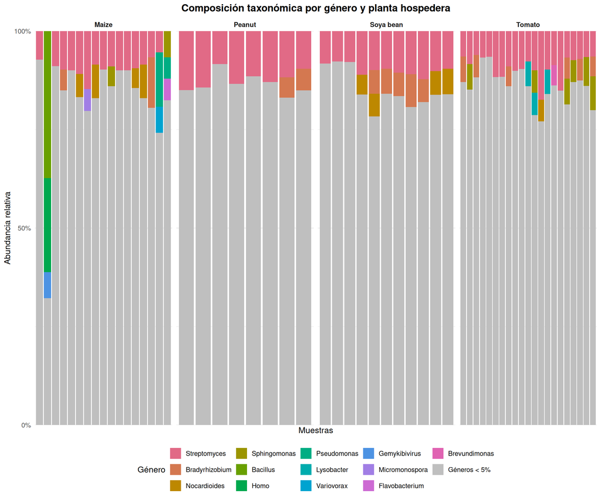

```r
# Ordenar los géneros por abundancia total y dejar "Géneros < 5%" al final
orden_generos <- generos_5_filtrado %>%
  filter(taxon_final != "Géneros < 5%") %>%
  group_by(taxon_final) %>%
  summarise(total = sum(abundancia_relativa)) %>%
  arrange(desc(total)) %>%
  pull(taxon_final)

niveles_gen <- c(orden_generos, "Géneros < 5%")

# Un color distinto por género y gris para "Géneros < 5%"
colores_gen <- setNames(
  c(hcl.colors(length(orden_generos), palette = "Dark 3"), "grey75"),
  niveles_gen
)

generos_5_filtrado <- generos_5_filtrado %>%
  mutate(taxon_final = factor(taxon_final, levels = niveles_gen))

# graficar
ggplot(generos_5_filtrado,
       aes(x = sample_id, y = abundancia_relativa, fill = taxon_final)) +
  geom_col(width = 0.9) +
  scale_fill_manual(values = colores_gen,
                    breaks = niveles_gen) +
  scale_y_continuous(breaks = c(0, 0.5, 1),
                     labels = function(x) paste0(round(100 * x), "%"),
                     expand = c(0, 0)) +
  labs(title = "Composición taxonómica por género y planta hospedera",
       x = "Muestras", y = "Abundancia relativa", fill = "Género") +
  facet_wrap(~ host_name, scales = "free_x", ncol = 4) +
  theme_minimal(base_size = 12) +
  theme(plot.title = element_text(face = "bold", hjust = 0.5),
        axis.text.x = element_blank(),
        axis.ticks.x = element_blank(),
        panel.grid.major.x = element_blank(),
        strip.text = element_text(face = "bold"),
        legend.position = "bottom") +
  guides(fill = guide_legend(nrow = 3))
```

Para discutir: ¿Qué diferencias observas en la composición taxonómica entre las plantas? ¿Todas las muestras de una misma planta presentan composiciones similares?

Las diferencias que observo entre la diversidad taxonómica de las plantas es que no todas están “gobernadas” por Pseudomonadota (es decir, que no ocupa la mayoría de la abundancia relativa). También, que no comparten entre ellas los mismos géneros.

## 10.12.2 Ejercicio 2

Utilizando `filos_5` y `metadata_riz`:

Identifica los países que tienen al menos 5 muestras.

```r
paises_5 <- metadata_riz %>%
  filter(sample_id %in% filos_5$sample_id) %>%
  count(country, name = "total_muestras") %>%
  filter(total_muestras >= 5) %>%
  arrange(desc(total_muestras))

print(paises_5)
```

```
# A tibble: 4 × 2
  country      total_muestras
  <chr>                 <int>
1 South Africa             27
2 China                    21
3 Mexico                   10
4 Netherlands               7
```

Conserva únicamente las muestras correspondientes a esos países.

```r
filos_5_country <- filos_5 %>%
  left_join(metadata_riz %>% select(sample_id, country), by = "sample_id") %>%
  filter(country %in% paises_5$country)
```

Construye una gráfica de barras apiladas de abundancia relativa por filo con `ggplot2`, utilizando `facet_wrap()` para comparar los países.

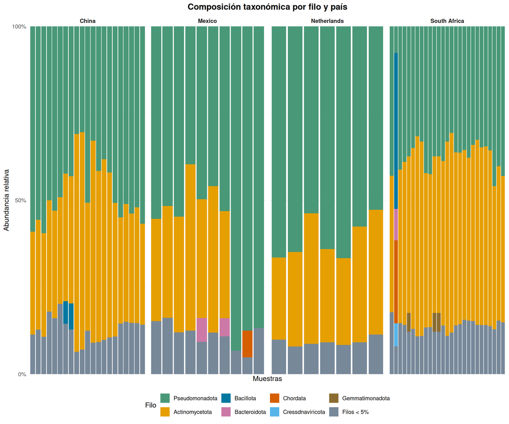

```r
# graficar
phylum_colors_rel <- c(
  "Pseudomonadota"   = "#499878",
  "Actinomycetota"   = "#E69F00",
  "Bacillota"        = "#0078A0",
  "Bacteroidota"     = "#CC79A7",
  "Chordata"         = "#D55E00",
  "Cressdnaviricota" = "#56B4E9",
  "Gemmatimonadota"  = "#8C6D31",
  "Filos < 5%"       = "#778899"
)

filos_5_country <- filos_5_country %>%
  mutate(taxon_final = factor(taxon_final, levels = names(phylum_colors_rel)))

ggplot(filos_5_country,
       aes(x = sample_id, y = abundancia_relativa, fill = taxon_final)) +
  geom_col(width = 0.9) +
  scale_fill_manual(values = phylum_colors_rel,
                    breaks = names(phylum_colors_rel)) +
  scale_y_continuous(breaks = c(0, 0.5, 1),
                     labels = function(x) paste0(round(100 * x), "%"),
                     expand = c(0, 0)) +
  labs(title = "Composición taxonómica por filo y país",
       x = "Muestras", y = "Abundancia relativa", fill = "Filo") +
  facet_wrap(~ country, scales = "free_x", ncol = 4) +
  theme_minimal(base_size = 12) +
  theme(plot.title = element_text(face = "bold", hjust = 0.5),
        axis.text.x = element_blank(),
        axis.ticks.x = element_blank(),
        panel.grid.major.x = element_blank(),
        strip.text = element_text(face = "bold"),
        legend.position = "bottom") +
  guides(fill = guide_legend(nrow = 2))
```

Para discutir: ¿Qué diferencias observas en la composición taxonómica entre los países? ¿Las muestras de un mismo país presentan composiciones similares?

De igual forma observo que no todos están gobernados por Pseudomonadota, que no todos albergan a los mismos taxones y también que no todos tienen la misma cantidad de taxones en su composición. Finalmente, observo que entre las muestras de un mismo país la composición también varía.